# Course Project - Practical Machine Learning

Huy Tran

October 14, 2015

### Project Descriptions

Using devices such as Jawbone Up, Nike FuelBand, and Fitbit it is now possible to collect a large amount of data about personal activity relatively inexpensively. These type of devices are part of the quantified self movement - a group of enthusiasts who take measurements about themselves regularly to improve their health, to find patterns in their behavior, or because they are tech geeks. One thing that people regularly do is quantify how much of a particular activity they do, but they rarely quantify how well they do it.

In this project, *I will use data from accelerometers on the belt, forearm, arm, and dumbell of 6 participants, and predict the manner in which they did the exercise*.They were asked to perform barbell lifts correctly and incorrectly in 5 different ways. More information is available from the website here: http://groupware.les.inf.puc-rio.br/har (see the section on the Weight Lifting Exercise Dataset).

Finally, I will also use your prediction model to predict 20 different test cases.

### 1. How the model is built:

#### **Data Reading**:

The firts step taken was to download the training and test data for this analysis come in the form of a comma-separated-value file, from the course web site. And, then the data is read to R for analysis.

And, Select all accelerometers variables which begin with “accel” and the outcome variable “classe”

```r
#downloading the training data
if (!file.exists("pml-training.csv")) {
    download.file("https://d396qusza40orc.cloudfront.net/predmachlearn/pml-training.csv",
                  destfile = "pml-training.csv")
}
#downloading the testing data
if (!file.exists("pml-testing.csv.csv")) {
    download.file("https://d396qusza40orc.cloudfront.net/predmachlearn/pml-testing.csv",
                  destfile = "pml-testing.csv")
}
#reading de training and testing data
pml_training<-read.csv("pml-training.csv")
pml_testing<-read.csv("pml-testing.csv")

varnames <- names(pml_training)
subsetnames <- grep("^accel|classe",varnames)

#creating a subset with the variables selected
training<- subset(pml_training,select=subsetnames)

names<-names(pml_testing)
subsetnames<-grep("^accel|classe",names)

#creating a subset with the variables selected
testing<-subset(pml_testing,select=subsetnames)
```

#### **Checking nearZero variance variables**

```r
nearZeroVar(training)
```

```
## integer(0)
```

This result is showing that none of the variables is having variance near Zero.

#### **Filtering high correlated variables**

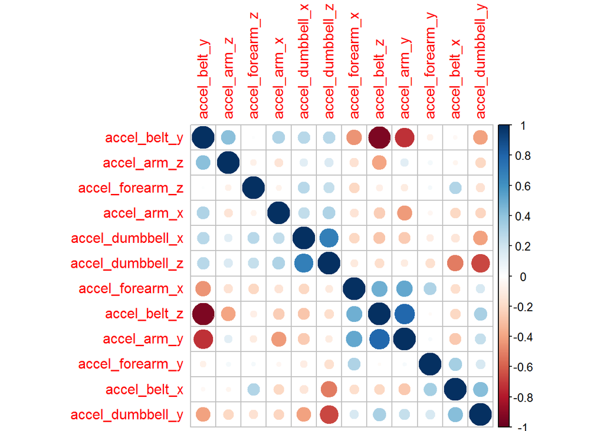

```r
correlations <- cor(training[,-13]) #except the classe as outcome variable
corrplot::corrplot(correlations, order="hclust")
```

From the result/plot, we remove the highly pair-wise correlations.

```r
highCorr <- findCorrelation(correlations, cutoff = 0.75)
filteredtraining <- training[,-highCorr]
filteredtesting <- testing[,-highCorr]
```

#### **Data visualization Analysis**

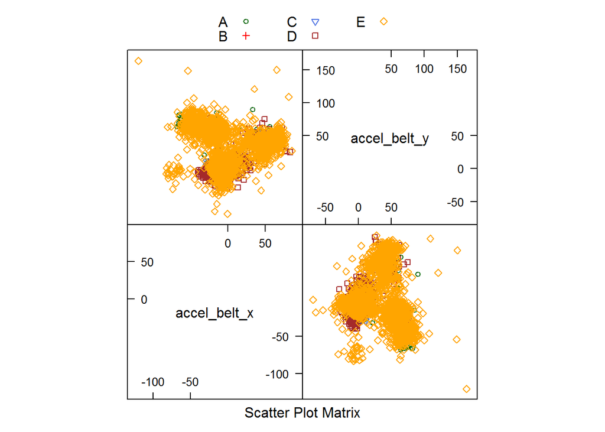

```r
library(AppliedPredictiveModeling)
transparentTheme(trans = .4)
trellis.par.set(theme = col.whitebg(), warn = FALSE)
library(caret)

featurePlot(x = filteredtraining[, 1:2],
             y = filteredtraining[,12],
             plot = "pairs",
             ## Add a key at the top
             auto.key = list(columns = 3))
```

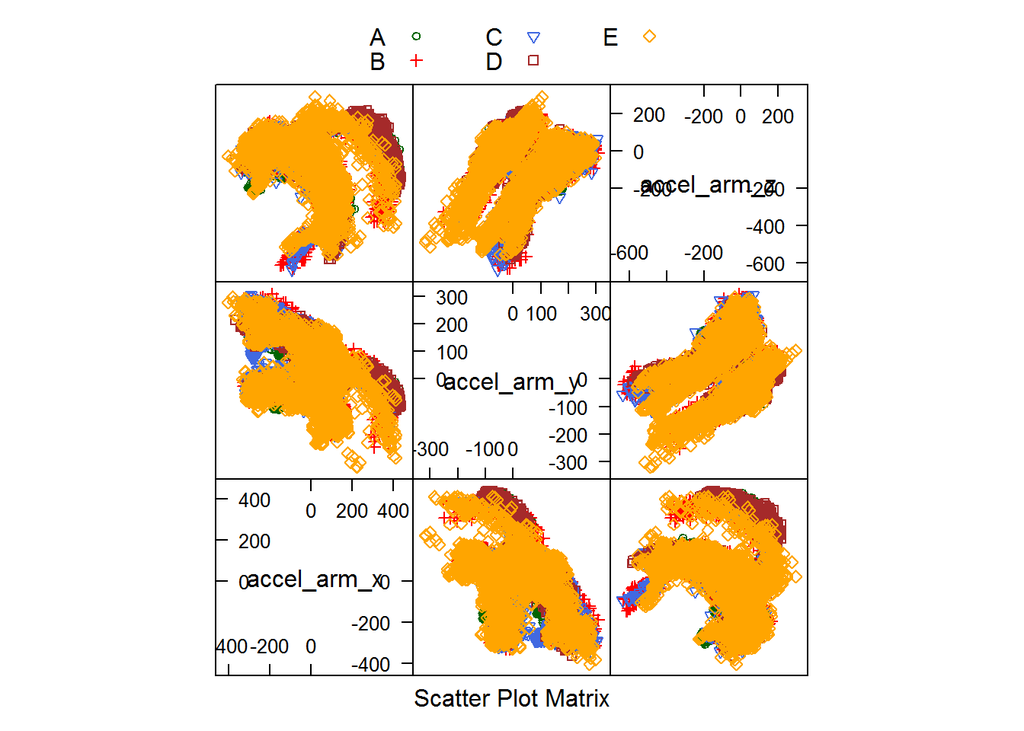

```r
featurePlot(x = filteredtraining[, 3:5],
             y = filteredtraining[,12],
             plot = "pairs",
             ## Add a key at the top
             auto.key = list(columns = 3))
```

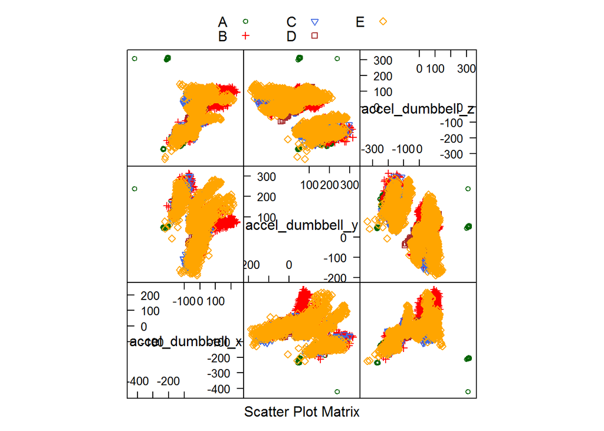

```r
featurePlot(x = filteredtraining[, 6:8],
             y = filteredtraining[,12],
             plot = "pairs",
             ## Add a key at the top
             auto.key = list(columns = 3))
```

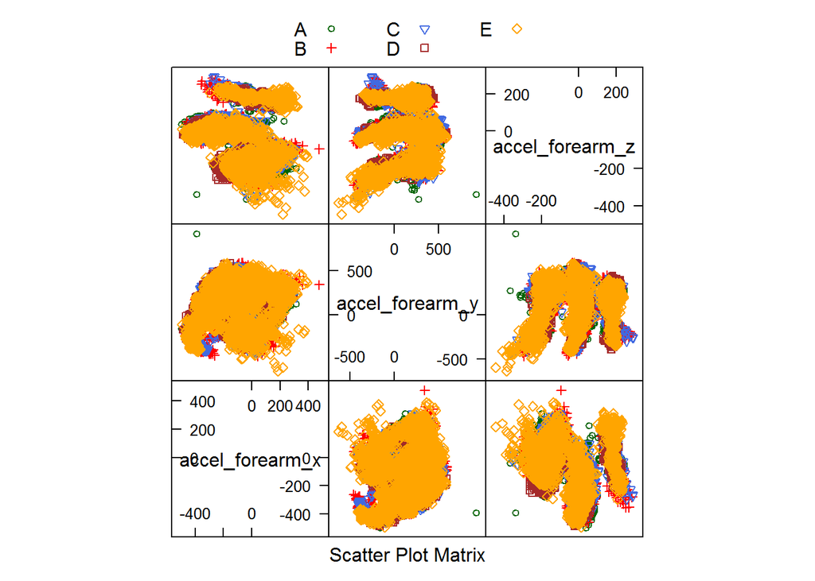

```r
featurePlot(x = filteredtraining[, 9:11],
             y = filteredtraining[,12],
             plot = "pairs",
             ## Add a key at the top
             auto.key = list(columns = 3))
```

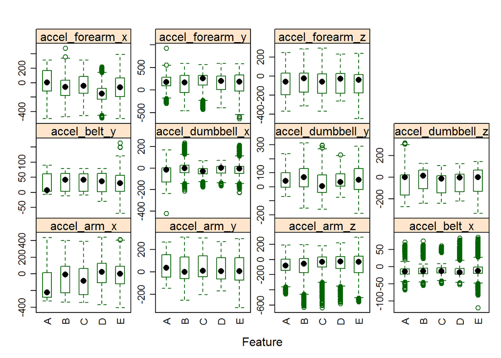

```r
featurePlot(x = filteredtraining[,-12],
                  y = filteredtraining[,12],
                  plot = "box",
                  ## Pass in options to bwplot()
                  scales = list(y = list(relation="free"),
                                x = list(rot = 90)),
                  layout = c(4,3),
                  auto.key = list(columns = 2))
```

*From the characteristic noise in the sensor data as we found on the visualization analysis, we use a Random Forest approach. This algorithm is characterized by a subset of features, selected in a random and independent manner with the same distribution for each of the trees in the forest.*

### 2. How cross validation is used:

In order to perform cross-validation, the training data set is partionned into 2 sets: subTraining (75%) and subTest (25%). This will be performed using random subsampling without replacement.

```r
set.seed(111)
inTrain <- createDataPartition(filteredtraining$classe, p=.75, list=FALSE)
subtraining <- filteredtraining[inTrain,]
subtesting <- filteredtraining[-inTrain,]
```

Preprocess the training data

```r
set.seed(111)
preProc95 <- preProcess(subtraining[, -12], method = c("center","scale","pca"), thresh = 0.95)
trainingPC <- predict(preProc95, subtraining[, -12])
testingPC <- predict(preProc95, subtesting[, -12])
```

Building model fit

```r
set.seed(111)

modelfit <- train(subtraining$classe ~., method = "rf", data = trainingPC
                  ,trControl = trainControl(method = "oob",  number = 4)
                  ,importance = TRUE)
summary(modelfit)
```

```
##                 Length Class      Mode
## call                5  -none-     call
## type                1  -none-     character
## predicted       14718  factor     numeric
## err.rate         3000  -none-     numeric
## confusion          30  -none-     numeric
## votes           73590  matrix     numeric
## oob.times       14718  -none-     numeric
## classes             5  -none-     character
## importance         56  -none-     numeric
## importanceSD       48  -none-     numeric
## localImportance     0  -none-     NULL
## proximity           0  -none-     NULL
## ntree               1  -none-     numeric
## mtry                1  -none-     numeric
## forest             14  -none-     list
## y               14718  factor     numeric
## test                0  -none-     NULL
## inbag               0  -none-     NULL
## xNames              8  -none-     character
## problemType         1  -none-     character
## tuneValue           1  data.frame list
## obsLevels           5  -none-     character
```

Cross-validating on the validation sample data.

The model fit is adjust via the control method to select the most performed models, Here is the confusion matrix and the statistics result of the selected model fit:

```r
confusionMatrix(subtesting$classe,predict(modelfit,testingPC))
```

```
## Confusion Matrix and Statistics
##
##           Reference
## Prediction    A    B    C    D    E
##          A 1295   14   44   38    4
##          B   68  809   27   23   22
##          C   26   18  780   20   11
##          D   37   15   41  701   10
##          E   13   40   25   31  792
##
## Overall Statistics
##
##                Accuracy : 0.8925
##                  95% CI : (0.8835, 0.9011)
##     No Information Rate : 0.2934
##     P-Value [Acc > NIR] : < 2.2e-16
##
##                   Kappa : 0.864
##  Mcnemar's Test P-Value : 1.847e-12
##
## Statistics by Class:
##
##                      Class: A Class: B Class: C Class: D Class: E
## Sensitivity            0.8999   0.9029   0.8506   0.8622   0.9440
## Specificity            0.9711   0.9651   0.9812   0.9748   0.9732
## Pos Pred Value         0.9283   0.8525   0.9123   0.8719   0.8790
## Neg Pred Value         0.9590   0.9780   0.9662   0.9727   0.9883
## Prevalence             0.2934   0.1827   0.1870   0.1658   0.1711
## Detection Rate         0.2641   0.1650   0.1591   0.1429   0.1615
## Detection Prevalence   0.2845   0.1935   0.1743   0.1639   0.1837
## Balanced Accuracy      0.9355   0.9340   0.9159   0.9185   0.9586
```

### 3. Using prediction model to predict 20 different test cases:

checking result on testing set

```r
trans_testing <- predict(preProc95,filteredtesting[,-12])
predicted<-predict(modelfit,newdata=trans_testing)
predicted
```

```
##  [1] B A B A A E D B A A B C B A E E A B B B
## Levels: A B C D E
```